# Mandatory: Supervised Learning II

## Description and exploratory analysis of the 'Abalone Age Prediction' dataset.

In this document, we'll be using the "Abalone Age Prediction" dataset which was appended in the course resources to perform exploratory data analysis (EDA) and preprocessing.

### Purpose of the Dataset

The purpose of the "Abalone Age Prediction" dataset is to predict the age of abalones from physical measurements. This can help in understanding the growth patterns of abalones and can be useful for fisheries management and conservation efforts.

### Dataset Overview

The dataset consists of several features that describe the physical characteristics of abalones, along with a target variable that indicates their age. The features include measurements such as length, diameter, height, whole weight, shucked weight, viscera weight, shell weight, and sex of the abalone.  
All features are numeric except for the "Sex" feature, which is categorical and indicates whether the abalone is male, female, or infant.

## Feature Description

The dataset contains the following features:

| Feature | Type | Description | Units |
| --- | --- | --- | --- |
| Sex | Categorical | M, F, and I (infant) | mm |
| Lenght | Continuous | Longest shell measurement | mm |
| Diameter | Continuous | perpendicular to length | mm |
| Height | Continuous | with meat in shell | grams |
| Whole_weight | Continuous | whole abalone | grams |
| Shucked_weight | Continuous | weight of meat | grams |
| Viscera_weight | Continuous | gut weight (after bleeding) | grams |
| Shell_weight | Continuous | after being dried | grams |

## Target Variable

Target variable is labled "Rings", has a numeric value.  
If I've understood the data correctly then the given target value + 1.5 should give the age if the Abalone.

| Target | Type | Description |
| --- | --- | --- |
| Rings | Integer | +1.5 gives the age in years |

## Exploratory Data Analysis (EDA)

In this section, we will perform exploratory data analysis to understand the distribution of features and the target variable, as well as identify any potential correlations or patterns in the data.

### Data import

We'll start by importing the necessary libraries to analyze the dataset and loading the dataset with pandas.  
For this analysis, we'll be dropping the target variable from the dataset to focus on the features only.

```python
import pandas as pd
import numpy as np
import matplotlib.pyplot as plt
import seaborn as sb
from sklearn.preprocessing import StandardScaler
from sklearn.decomposition import PCA
```

### Custom Functions for Analysis

To facilitate the analysis of the dataset, we'll define some custom functions that can help us visualize and understand the data better.

```python
def get_df_name(df):
    name =[x for x in globals() if globals()[x] is df][0]
    return name

def corr_matrix(df):
    numCorr1 = df.corr()
    fig, ax = plt.subplots(1,1, figsize=(23,7))
    sb.heatmap(numCorr1, annot=True, cmap='coolwarm', ax=ax)
    ax.set_title(get_df_name(df))

def target_bar(df1):
    fig, ax = plt.subplots(1, 1, figsize=(10, 5))
    sb.countplot(x="Target", data=df1, ax=ax)
    ax.set_title(get_df_name(df1))
    ax.set_xlabel("Target")
    ax.set_ylabel("Count")
    plt.tight_layout()
```

```python
abalone_df = pd.read_csv('../data/abalone.csv', sep=',', names=[
    "sex",
    "length",
    "diameter",
    "height",
    "whole_weight",
    "shucked_weight",
    "viscera_weight",
    "shell_weight",
    "rings"
])
abalone_df_X = abalone_df.drop(columns=['rings'])
abalone_df_y = abalone_df[['rings']]
abalone_df.head()
```

|  | sex | length | diameter | height | whole_weight | shucked_weight | viscera_weight | shell_weight | rings |
| --- | --- | --- | --- | --- | --- | --- | --- | --- | --- |
| 0 | M | 0.455 | 0.365 | 0.095 | 0.5140 | 0.2245 | 0.1010 | 0.150 | 15 |
| 1 | M | 0.350 | 0.265 | 0.090 | 0.2255 | 0.0995 | 0.0485 | 0.070 | 7 |
| 2 | F | 0.530 | 0.420 | 0.135 | 0.6770 | 0.2565 | 0.1415 | 0.210 | 9 |
| 3 | M | 0.440 | 0.365 | 0.125 | 0.5160 | 0.2155 | 0.1140 | 0.155 | 10 |
| 4 | I | 0.330 | 0.255 | 0.080 | 0.2050 | 0.0895 | 0.0395 | 0.055 | 7 |

### Validation of Data types

#### Dataset Information

It's important to validate that the data types of each feature are appropriate for analysis.  
We can use the `info()` method from pandas to check the data types and non-null counts of each column in the dataset.  
From the output in the next cell, we can see that all features have the correct data types and there are no missing values in the dataset.

```python
abalone_df.info()
```

```
<class 'pandas.core.frame.DataFrame'>
RangeIndex: 4177 entries, 0 to 4176
Data columns (total 9 columns):
 #   Column          Non-Null Count  Dtype
---  ------          --------------  -----
 0   sex             4177 non-null   object
 1   length          4177 non-null   float64
 2   diameter        4177 non-null   float64
 3   height          4177 non-null   float64
 4   whole_weight    4177 non-null   float64
 5   shucked_weight  4177 non-null   float64
 6   viscera_weight  4177 non-null   float64
 7   shell_weight    4177 non-null   float64
 8   rings           4177 non-null   int64
dtypes: float64(7), int64(1), object(1)
memory usage: 293.8+ KB
```

#### Dataset Description

Next we'll use the `describe()` method from pandas to get a statistical summary of the numerical features in the dataset. Here we can see the count, mean, standard deviation, minimum, maximum, and quartiles for each numerical feature.

```python
abalone_df.describe()
```

|  | length | diameter | height | whole_weight | shucked_weight | viscera_weight | shell_weight | rings |
| --- | --- | --- | --- | --- | --- | --- | --- | --- |
| count | 4177.000000 | 4177.000000 | 4177.000000 | 4177.000000 | 4177.000000 | 4177.000000 | 4177.000000 | 4177.000000 |
| mean | 0.523992 | 0.407881 | 0.139516 | 0.828742 | 0.359367 | 0.180594 | 0.238831 | 9.933684 |
| std | 0.120093 | 0.099240 | 0.041827 | 0.490389 | 0.221963 | 0.109614 | 0.139203 | 3.224169 |
| min | 0.075000 | 0.055000 | 0.000000 | 0.002000 | 0.001000 | 0.000500 | 0.001500 | 1.000000 |
| 25% | 0.450000 | 0.350000 | 0.115000 | 0.441500 | 0.186000 | 0.093500 | 0.130000 | 8.000000 |
| 50% | 0.545000 | 0.425000 | 0.140000 | 0.799500 | 0.336000 | 0.171000 | 0.234000 | 9.000000 |
| 75% | 0.615000 | 0.480000 | 0.165000 | 1.153000 | 0.502000 | 0.253000 | 0.329000 | 11.000000 |
| max | 0.815000 | 0.650000 | 1.130000 | 2.825500 | 1.488000 | 0.760000 | 1.005000 | 29.000000 |

From the description we can do the following observation:

#### Center and Spread

[output not shown]

### Feature Types Summary

Based on the dataset information, we can summarize the feature types as follows:

| Type | Examples | Notes |
| --- | --- | --- |
| **Categorical (String)** | `sex` | Consider using one-hot encoding for this feature, or drop it if not useful. |
| **Continuous (Numeric)** | `length`, `diameter`, `height`, `whole_weight`, `shucked_weight`, `viscera_weight`, `shell_weight` | Suitable for correlation and distribution analysis. |

### One Hot Encoding of Categorical Features

To handle categorical features in the dataset, we can use one-hot encoding to convert them into a format suitable for machine learning algorithms. This would also simplify further analysis of correlations between features.

```python
abalone_df_X = pd.get_dummies(abalone_df_X, columns=["sex"], prefix="sex")
abalone_df_X.head()
```

|  | length | diameter | height | whole_weight | shucked_weight | viscera_weight | shell_weight | sex_F | sex_I | sex_M |
| --- | --- | --- | --- | --- | --- | --- | --- | --- | --- | --- |
| 0 | 0.455 | 0.365 | 0.095 | 0.5140 | 0.2245 | 0.1010 | 0.150 | False | False | True |
| 1 | 0.350 | 0.265 | 0.090 | 0.2255 | 0.0995 | 0.0485 | 0.070 | False | False | True |
| 2 | 0.530 | 0.420 | 0.135 | 0.6770 | 0.2565 | 0.1415 | 0.210 | True | False | False |
| 3 | 0.440 | 0.365 | 0.125 | 0.5160 | 0.2155 | 0.1140 | 0.155 | False | False | True |
| 4 | 0.330 | 0.255 | 0.080 | 0.2050 | 0.0895 | 0.0395 | 0.055 | False | True | False |

```python
abalone_df_X.describe()
```

|  | length | diameter | height | whole_weight | shucked_weight | viscera_weight | shell_weight |
| --- | --- | --- | --- | --- | --- | --- | --- |
| count | 4177.000000 | 4177.000000 | 4177.000000 | 4177.000000 | 4177.000000 | 4177.000000 | 4177.000000 |
| mean | 0.523992 | 0.407881 | 0.139516 | 0.828742 | 0.359367 | 0.180594 | 0.238831 |
| std | 0.120093 | 0.099240 | 0.041827 | 0.490389 | 0.221963 | 0.109614 | 0.139203 |
| min | 0.075000 | 0.055000 | 0.000000 | 0.002000 | 0.001000 | 0.000500 | 0.001500 |
| 25% | 0.450000 | 0.350000 | 0.115000 | 0.441500 | 0.186000 | 0.093500 | 0.130000 |
| 50% | 0.545000 | 0.425000 | 0.140000 | 0.799500 | 0.336000 | 0.171000 | 0.234000 |
| 75% | 0.615000 | 0.480000 | 0.165000 | 1.153000 | 0.502000 | 0.253000 | 0.329000 |
| max | 0.815000 | 0.650000 | 1.130000 | 2.825500 | 1.488000 | 0.760000 | 1.005000 |

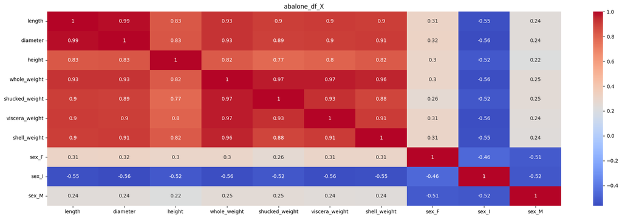

```python
corr_matrix(abalone_df_X)
```

### Heatmap of Feature Correlations

So here we can observe that there are several strong positive correlations among continous features in the dataset. This suggest a high degree of [multicollinearity](https://en.wikipedia.org/wiki/Multicollinearity), meaning that many of these features holds overlapping information about the size and weight of the abalones.

[output not shown]

### Feature Distributions

To understand the distribution of each feature in the dataset, we can visualize them using histograms or density plots.  
This can help us identify any skewness, outliers, or unusual patterns in the data.  
In the histograms below, we can see the distributions of all features in the dataset. Here we can see that there are several features with skewed distributions which may require transformation or normalization before using them in machine learning models.  
Such patterns suggest that transformations (e.g., log or power scaling), normalization, or categorical re-encoding may be required to improve model performance. Additionally, features with near-constant values or excessive sparsity may contribute little predictive power and could be considered for removal.

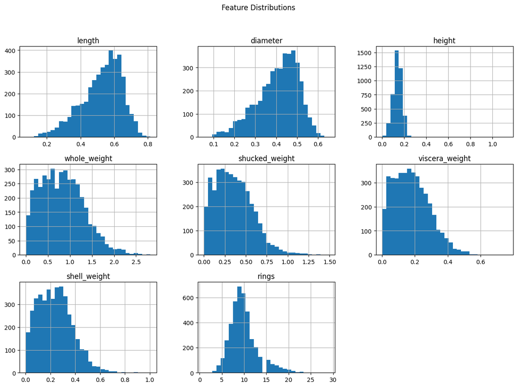

```python
abalone_df.hist(figsize=(15,10), bins=30)
plt.suptitle('Feature Distributions')
```

### Distribution Interpretation

Most features have continuous, positively skewed (right-skewed) distributions.  
This means most abalones are smaller and lighter, with fewer large or heavy specimens, which makes sense in a natural population.

#### Detailed Interpretation

[output not shown]

### Scaling and Normalizing (StandardScaler, PCA)

Based on the current observations and interpertation, we'll try to do some adjustemts to the current features.  
In this section we'll use `StandardScaler` and `PCA` to try and make the features more amendable for training models.

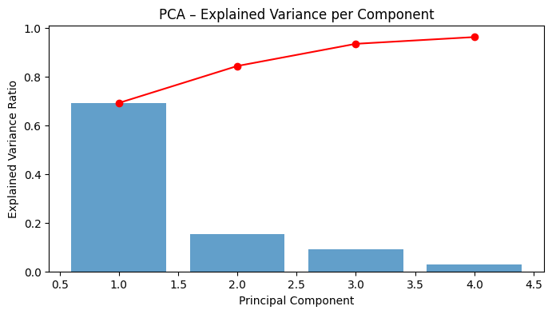

```python
# Standardizing the features
abalone_df_X_scaled = StandardScaler().fit_transform(abalone_df_X)

# Applying PCA
pca = PCA(n_components=0.95)  # Retain 95% of variance
abalone_df_X_pca = pca.fit_transform(abalone_df_X_scaled)

# Step 3: Plot explained variance ratio
plt.figure(figsize=(8, 4))
plt.bar(range(1, len(pca.explained_variance_ratio_) + 1), pca.explained_variance_ratio_, alpha=0.7)
plt.plot(range(1, len(pca.explained_variance_ratio_) + 1),
         pca.explained_variance_ratio_.cumsum(), marker='o', color='red')
plt.xlabel('Principal Component')
plt.ylabel('Explained Variance Ratio')
plt.title('PCA – Explained Variance per Component')
plt.show()
```

### Takeaways from PCA plot

This indicates nearly all meaningful variability in abalone physical measurements can be represented in 2–3 orthogonal directions.

#### Putting it all together

Now that we should have a preformed scaling and dimensionality reduction of the dataset, we can prepare the final dataset for training machine learning models, by combining the PCA-transformed features with the target variable.

```python
abalone_pca_df = pd.DataFrame(abalone_df_X_pca, columns=[f'PC{i+1}' for i in range(abalone_df_X_pca.shape[1])])
abalone_pca_df['rings'] = abalone_df_y.reset_index(drop=True)
```

#### Evaluation of final dataset

To evaluate the final preprocessed dataset, we can visualize the correlation matrix and feature distributions again to ensure that the transformations have improved the data quality.  
We can also check for any remaining outliers or anomalies that may affect model training.

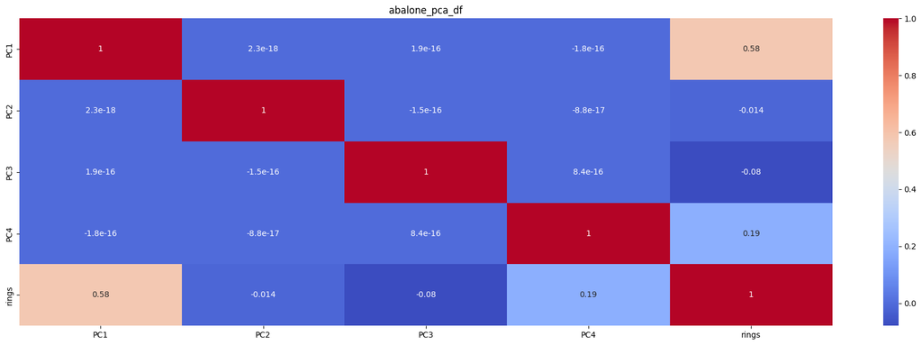

```python
corr_matrix(abalone_pca_df)
```

Based on the correlation matrix we can see that the PCA-transformed features are now uncorrelated with each other, as expected.  
The target variable `rings` still shows some correlation with the `PC1` components, indicating that they still capture relevant information for predicting abalone age.

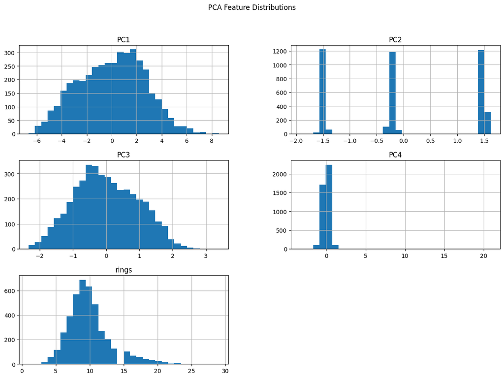

```python
abalone_pca_df.hist(figsize=(15,10), bins=30)
plt.suptitle('PCA Feature Distributions')
```

#### PCA Feature Distributions

After standardization and PCA, each principal component is a linear combination of the original features.

[output not shown]

### Export Processed Data

Finally, we can export the preprocessed dataset to a CSV file for use in training machine learning models. For this case we'll export two sets of data:

1. The full PCA-transformed dataset including all principal components and the target variable.
2. A reduced dataset where `PC4` is dropped due to its minimal contribution to variance.

```python
final_abalone_df = abalone_pca_df.copy()
final_abalone_df_reduced = final_abalone_df.drop(columns=['PC4'])
final_abalone_df.to_csv('../data/abalone_processed_full.csv', index=False)
final_abalone_df_reduced.to_csv('../data/abalone_processed_reduced.csv', index=False)
```